# Data Analysis on Activity Dataset

Asad Husain

25/03/2020

Welcome to this data analysis report! I have made this report so as to analyse the data on the activity dataset as intructed in the week 2 peer graded assignment of Reproducible Research course on Coursera. Enjoy.

## Loading relevant libraries

```r
options(warn = -1)
library(dplyr)
```

```r
library(ggplot2)
```

## Loading and Pre-Processing the data

Set the working directory according to your file manager. I have stored the data in a aptly named variable called `act`.

```r
#setwd("..\redata_data_activity")
act <- read.csv("activity.csv")
act <- tbl_df(act)
act_na <- na.omit(act)
```

```r
dim(act)
```

```
## [1] 17568     3
```

```r
str(act)
```

```
## Classes 'tbl_df', 'tbl' and 'data.frame':    17568 obs. of  3 variables:
##  $ steps   : int  NA NA NA NA NA NA NA NA NA NA ...
##  $ date    : Factor w/ 61 levels "2012-10-01","2012-10-02",..: 1 1 1 1 1 1 1 1 1 1 ...
##  $ interval: int  0 5 10 15 20 25 30 35 40 45 ...
```

```r
summary(act)
```

```
##      steps                date          interval
##  Min.   :  0.00   2012-10-01:  288   Min.   :   0.0
##  1st Qu.:  0.00   2012-10-02:  288   1st Qu.: 588.8
##  Median :  0.00   2012-10-03:  288   Median :1177.5
##  Mean   : 37.38   2012-10-04:  288   Mean   :1177.5
##  3rd Qu.: 12.00   2012-10-05:  288   3rd Qu.:1766.2
##  Max.   :806.00   2012-10-06:  288   Max.   :2355.0
##  NA's   :2304     (Other)   :15840
```

As we can see that the second column contains dates but is formatted as factor variable. We should change that to Date format using mutate command from dplyr library.

```r
act <- act %>%
        mutate(date = as.Date(date, "%Y-%m-%d"))
```

## Mean of Steps

```r
by_date <- act_na %>%
        group_by(date)
by_date_steps <- by_date %>%
        summarise(Steps_sum = sum(steps))
by_date_steps
```

```
## # A tibble: 53 x 2
##    date       Steps_sum
##    <fct>          <int>
##  1 2012-10-02       126
##  2 2012-10-03     11352
##  3 2012-10-04     12116
##  4 2012-10-05     13294
##  5 2012-10-06     15420
##  6 2012-10-07     11015
##  7 2012-10-09     12811
##  8 2012-10-10      9900
##  9 2012-10-11     10304
## 10 2012-10-12     17382
## # ... with 43 more rows
```

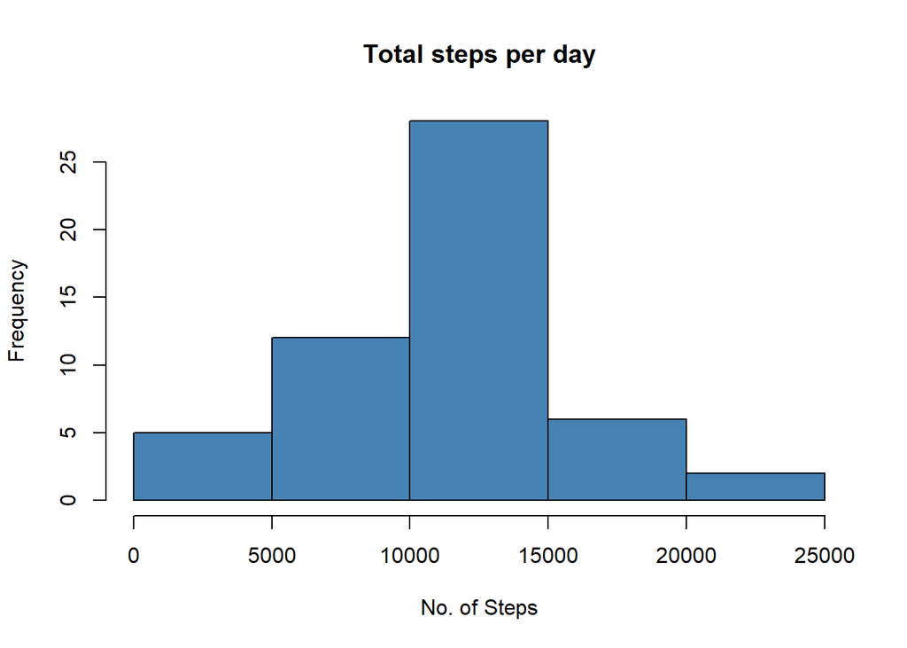

```r
hist(by_date_steps$Steps_sum, main = "Total steps per day", xlab = "No. of Steps", col = "Steelblue")
```

```r
mean_steps <- as.integer(mean(by_date_steps$Steps_sum))
median_steps <- median(by_date_steps$Steps_sum)
```

- Mean of Total steps taken per day comes out to be **10766**.
- Median of Total steps taken per day comes out to be **10765**.

## Average Daily Activity Pattern

```r
by_interval <- act_na %>%
        group_by(interval)
by_interval_steps <- by_interval %>%
        summarise(Steps_mean = mean(steps))
by_interval_steps
```

```
## # A tibble: 288 x 2
##    interval Steps_mean
##       <int>      <dbl>
##  1        0     1.72
##  2        5     0.340
##  3       10     0.132
##  4       15     0.151
##  5       20     0.0755
##  6       25     2.09
##  7       30     0.528
##  8       35     0.868
##  9       40     0
## 10       45     1.47
## # ... with 278 more rows
```

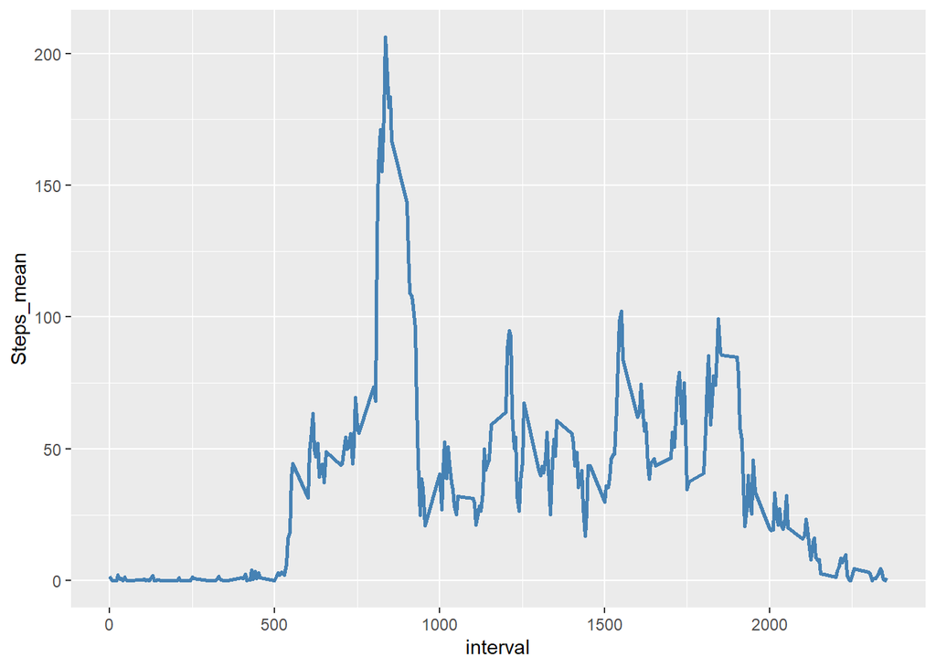

```r
tsplot1 <- ggplot(data = by_interval_steps, aes(x = interval, y= Steps_mean))
tsplot1 + geom_line(col = "steelblue", lwd = 1)
```

```r
filter(by_interval_steps, Steps_mean == max(Steps_mean))
```

```
## # A tibble: 1 x 2
##   interval Steps_mean
##      <int>      <dbl>
## 1      835       206.
```

## Imputing Missing Values

```r
tot_na <- sum(is.na(act$steps))
```

The total number of rows with NA is **2304**.

```r
#Filling the mean steps taken in that 5-minute intervals to replace NAs
act_new <- act
for (i in 1:nrow(act_new)){
        p <- filter(by_interval_steps, interval == as.integer(act_new[i,3]))
        if(is.na(act_new[i,1]))
        act_new[i, 1] <- as.integer(p[, 2])
}
```

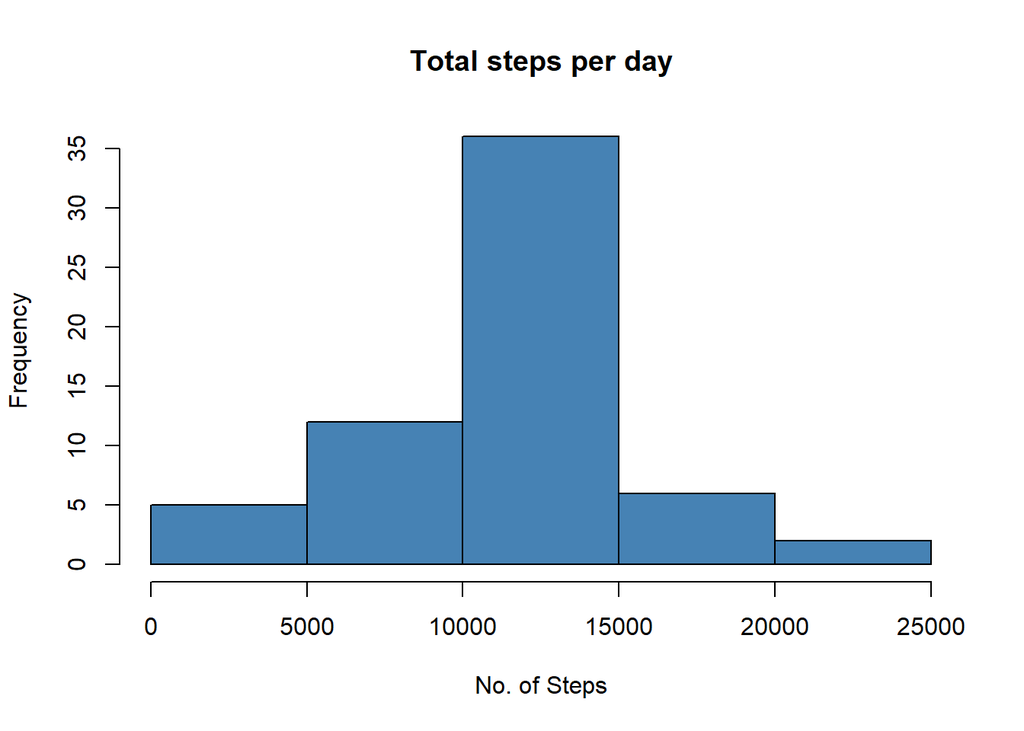

```r
by_date_new <- act_new %>%
        group_by(date) %>%
        summarise(Steps_sum = sum(steps))

hist(by_date_new$Steps_sum, main = "Total steps per day", xlab = "No. of Steps", col = "Steelblue")
```

```r
mean_steps_new <- as.integer(mean(by_date_new$Steps_sum))
median_steps_new <- median(by_date_new$Steps_sum)
```

- Mean of Total steps taken per day comes out to be **10749**.
- Median of Total steps taken per day comes out to be **10641**.

**YES!** Mean and Median have changed after replacing the NAs in the dataset. The mean of the dataset has slightly decreased by *17 step* and the median of the dataset has decreased by *124 steps*. The decrease in the estimates was expected as the denominator *(the number of row)* increased by 2304 *(the number of NA rows)* but the numerator *(steps)* did not increase in that scale.

## Comparing Weekdays and Weekends

```r
act_new <- act_new %>%
        mutate(day = weekdays(date))

for (i in 1:nrow(act_new)){
        if(act_new$day[i] %in% c("Sunday", "Saturday"))
                act_new[i, 4] <- "weekend"
        else(act_new[i, 4] <- "weekday")
}
act_new$day <- as.factor(act_new$day)
```

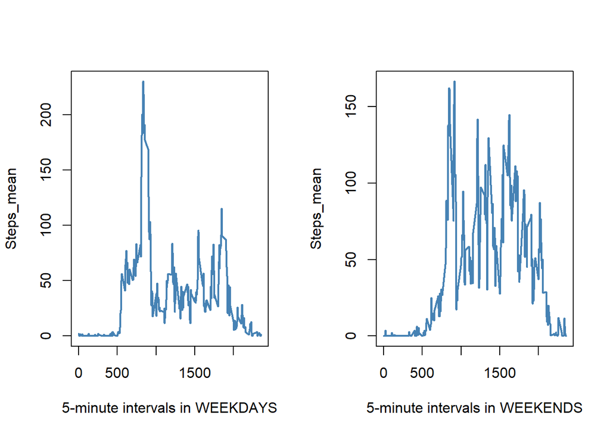

```r
by_interval_new_wday <- act_new %>%
        filter(day == "weekday") %>%
        group_by(interval) %>%
        summarise(Steps_mean = mean(steps))
by_interval_new_wend <- act_new %>%
        filter(day == "weekend") %>%
        group_by(interval) %>%
        summarise(Steps_mean = mean(steps))

par(mfrow = c(1,2))
plot(by_interval_new_wday, type = "l", col = "steelblue", lwd = 2, xlab = "5-minute intervals in WEEKDAYS")
plot(by_interval_new_wend, type = "l", col = "steelblue", lwd = 2, xlab = "5-minute intervals in WEEKENDS")
```

It can be clearly inferred from the panel plot that activity during weekend evenings is higher when compared to weekdays since during weekends avg. steps taken increase in the later part of the day when compared to weekdays.